# Assignment12_Summer19_Grace_Lang

Grace Lang

7/27/2019

# Warm Up: Brief Financial Data (20%):

Create a rudimentary plot of the data. In 1997, an event happened you want to indicate; add a vertical red line to your plot which divides pre-1997 and post-1997 information.

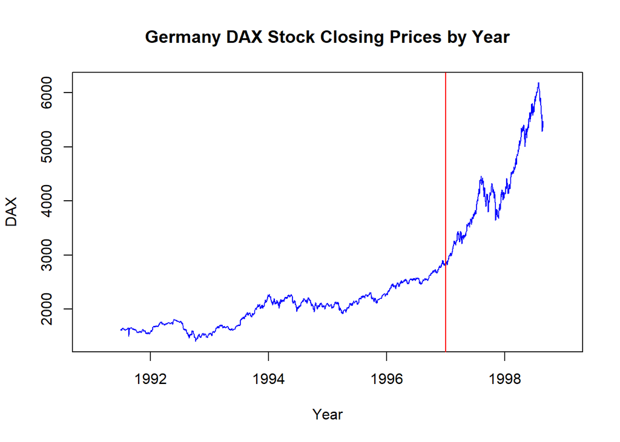

```r
df <- EuStockMarkets[,1]


plot(df,ylab = "DAX", xlab = "Year",main = "Germany DAX Stock Closing Prices by Year",xlim = c(1991, 1999), col="blue")
abline(v=1997,col="red")
```

Decompose the time series into its components (i.e., trend, seasonality, random). Keep in mind that this is a multiplicative model you want. Create a plot of all decomposed components. As before, make all lines blue and have a vertical divider at the year 1997.

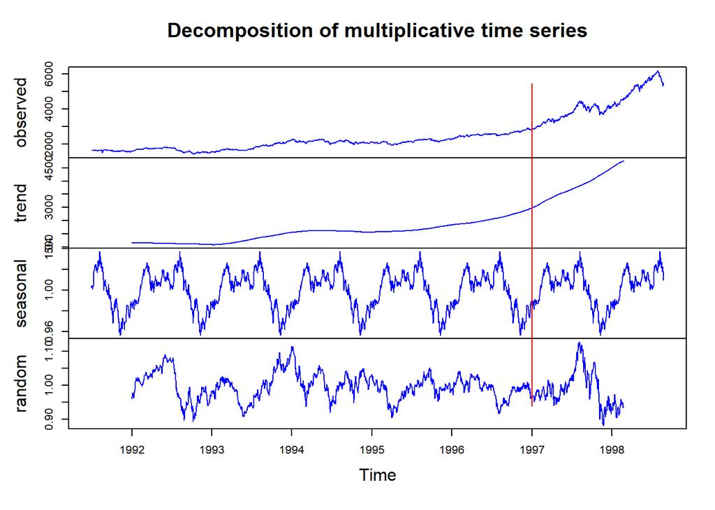

```r
dax2 <- decompose(df, type = "multiplicative")

plot(dax2, col="blue")
abline(v=1997,col="red")
```

# Temperature Data (40%):

Use the maxtemp dataset. To see what you’re looking at, execute the command in ‘Examples’ in the help document. Create TS of 1990 +.

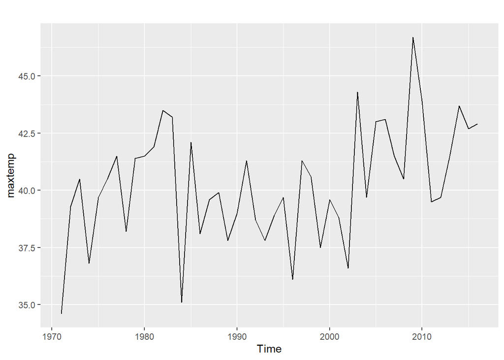

```r
autoplot(maxtemp)
```

```r
temp <- window(maxtemp,start = 1990)
```

Utilize SES to predict the next five years of maximum temperatures in Melbourne. So, to review, you should have your fit, the predicted value line overlaying it, and a forecast through 2021, all on one axis.

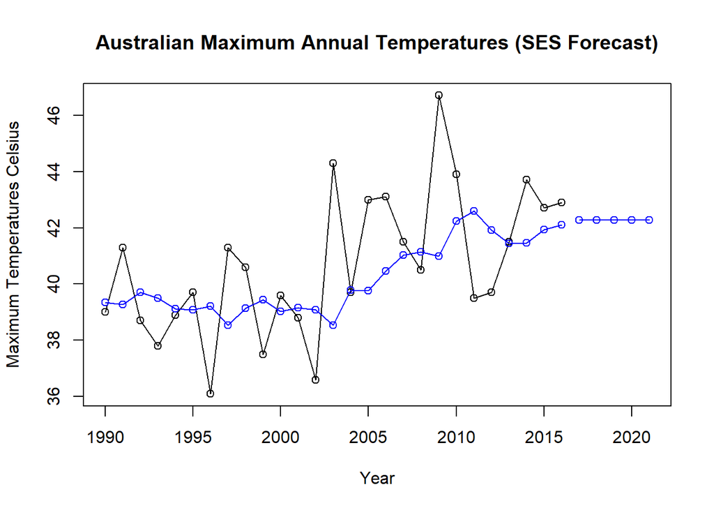

```r
ses_fit_5 = ses(temp, h = 5) #defaults, not clarified in hw


plot(temp,main = "Australian Maximum Annual Temperatures (SES Forecast)",ylab = "Maximum Temperatures Celsius", xlab = "Year", type = "o", xlim = c(1990, 2021))
lines(fitted(ses_fit_5), col = "blue", type = "o")
lines(ses_fit_5$mean, col = "blue", type = "o")
```

Find the AIC and BIC of this fitted model.

```r
summary(ses_fit_5)
```

```
##
## Forecast method: Simple exponential smoothing
##
## Model Information:
## Simple exponential smoothing
##
## Call:
##  ses(y = temp, h = 5)
##
##   Smoothing parameters:
##     alpha = 0.2164
##
##   Initial states:
##     l = 39.345
##
##   sigma:  2.4135
##
##      AIC     AICc      BIC
## 140.4868 141.5302 144.3743
##
## Error measures:
##                     ME     RMSE      MAE      MPE     MAPE      MASE
## Training set 0.5018493 2.322345 1.776513 0.947593 4.301593 0.7390293
##                     ACF1
## Training set -0.09460844
##
## Forecasts:
##      Point Forecast    Lo 80    Hi 80    Lo 95    Hi 95
## 2017       42.27727 39.18431 45.37024 37.54700 47.00755
## 2018       42.27727 39.11272 45.44183 37.43750 47.11704
## 2019       42.27727 39.04271 45.51184 37.33043 47.22411
## 2020       42.27727 38.97418 45.58036 37.22563 47.32891
## 2021       42.27727 38.90705 45.64750 37.12296 47.43158
```

Now use a damped Holt’s linear trend to also predict out five years.  
**SES fit is blue & Holt fit is dark green.**

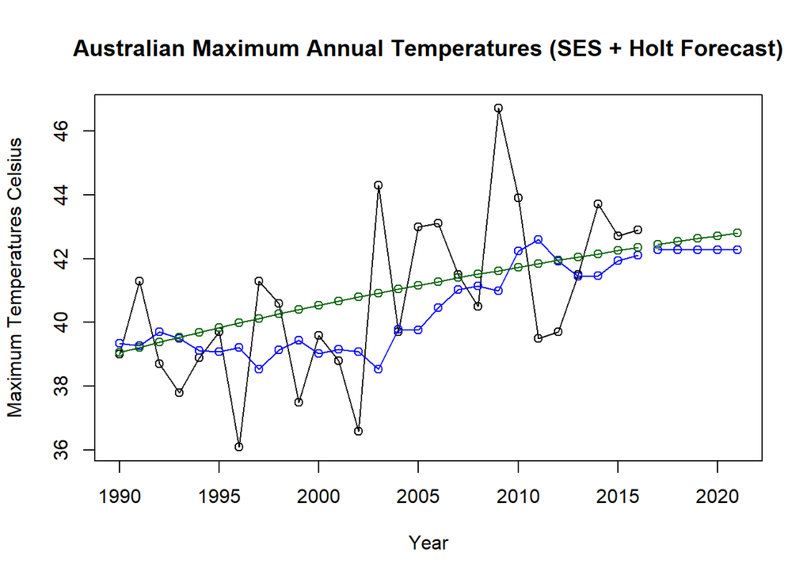

```r
holt_fit = holt(temp, damped = TRUE, initial = "optimal", h = 5)

plot(temp,main = "Australian Maximum Annual Temperatures (SES + Holt Forecast)",ylab = "Maximum Temperatures Celsius", xlab = "Year", type = "o", xlim = c(1990, 2021))
lines(fitted(ses_fit_5), col = "blue", type = "o")
lines(ses_fit_5$mean, col = "blue", type = "o")
lines(fitted(holt_fit), col = "darkgreen", type= "o")
lines(holt_fit$mean,col = "darkgreen", type= "o")
```

Compare the AICc and BIC of the ses() and holt() models. Which model is better here?

The SES Model has an AIC of 140.5 and a BIC of 144.4. The damped Holt Model has an AIC of 141.4 and a BIC of 149.2. Since the SES Model has a lower AIC & BIC it is the better fit in this comparison.

```r
summary(holt_fit)
```

```
##
## Forecast method: Damped Holt's method
##
## Model Information:
## Damped Holt's method
##
## Call:
##  holt(y = temp, h = 5, damped = TRUE, initial = "optimal")
##
##   Smoothing parameters:
##     alpha = 1e-04
##     beta  = 1e-04
##     phi   = 0.98
##
##   Initial states:
##     l = 38.8993
##     b = 0.1678
##
##   sigma:  2.3409
##
##      AIC     AICc      BIC
## 141.3865 145.5865 149.1615
##
## Error measures:
##                      ME     RMSE      MAE       MPE     MAPE      MASE
## Training set -0.1536912 2.113041 1.674417 -0.667571 4.132949 0.6965577
##                     ACF1
## Training set -0.01925071
##
## Forecasts:
##      Point Forecast    Lo 80    Hi 80    Lo 95    Hi 95
## 2017       42.43990 39.43995 45.43986 37.85187 47.02794
## 2018       42.53313 39.53317 45.53308 37.94509 47.12116
## 2019       42.62449 39.62453 45.62444 38.03645 47.21252
## 2020       42.71402 39.71406 45.71397 38.12598 47.30205
## 2021       42.80176 39.80181 45.80171 38.21373 47.38979
```

Calculate and compare the ASE from the ses() and holt() models. Which one performs better with respect to this metric?

In reference to the ASE metric, the Holt Model performs better with a lower ASE versus the SES Model.

```r
ase_ses <- (ses_fit_5$residuals)^2
ase_holt <- (holt_fit$residuals)^2

#mean(ase_ses)
#mean(ase_holt)

sum(ase_ses)/(27-1)
```

```
## [1] 5.600719
```

```r
sum(ase_holt)/(27-1)
```

```
## [1] 4.63667
```

# The Wands Choose the Wizard (40%):

Utilize the dygraphs library. Read in both Unit12TimeSeries_Ollivander and _Gregorovitch.csv as two different data frames. They do not have headers, so make sure you account for that. This is a time series of Wands sold over years.

```r
greg_url <- "https://raw.githubusercontent.com/BivinSadler/MSDS-6306-Doing-Data-Science/master/Unit%2012/Unit12TimeSeries_Gregorovitch.csv"
oliv_url <- "https://raw.githubusercontent.com/BivinSadler/MSDS-6306-Doing-Data-Science/master/Unit%2012/Unit12TimeSeries_Ollivander.csv"

greg = read.table(greg_url, header = FALSE, sep = ",")
oliv = read.table(oliv_url, header = FALSE, sep=",")

greg$V1 <- as.Date(greg$V1, format = "%m/%d/%Y")
oliv$V1 <- as.Date(oliv$V1, format = "%m/%d/%Y")

greg_ts <- xts(x = greg[[2]], order.by = greg[[1]])
oliv_ts <- xts(x = oliv[[2]], order.by = oliv[[1]])
```

Bind the two xts objects together and create a dygraph from it.

```r
comb <- cbind(greg_ts,oliv_ts)


dygraph(comb, main = "Number of Wands Sold by Year & Wandmaker", xlab = "Years in Business", ylab = "Number of Wands Sold")  %>% dyRangeSelector(height = 100) %>% dyRangeSelector(height = 50) %>% dySeries("greg_ts", label = "Gregorovitch") %>% dySeries("oliv_ts", label = "Ollivander") %>% dyOptions(stackedGraph = TRUE, colors = c("orange","purple")) %>% dyShading(from = "1995-01-01",to = "1999-01-01", color = "#b1b5b3") %>% dyHighlight(highlightSeriesOpts = list(strokeWidth = 3))
```

[interactive chart not shown]

**Note: The dark shaded gray area is the years that Voldemort was alive and at large.**